# **Analiza i wizualizacja danych**

## Lab 8. Biblioteka matplotlib, część 1 - zadania

**Zadanie 1**  
Stwórz i wyświetl wykres liniowy funkcji f(x) = 1/x dla x ϵ [1, 20]. Opisz linię wykresu dodając legendę z etykietą f(x) = 1/x. Dodaj odpowiednie etykiety do obu osi wykresu (‘x’, ’f(x)’) oraz ustaw zakres osi na (0, 1) oraz (0, długość wektora x).

**Zadanie 2**  
Zmodyfikuj wykres z zadania 1 tak, żeby styl wykresu wyglądał tak jak poniżej.

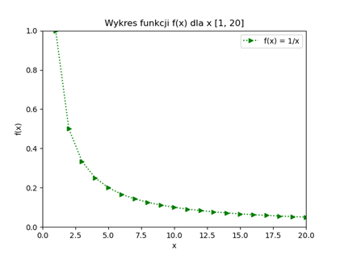

**Zadanie 3**  
Na jednym wykresie wygeneruj wykresy funkcji sin(x) oraz cos(x) dla x ϵ [0, 30] z krokiem 0.1. Dodaj etykiety i legendę do wykresu.

**Zadanie 4**  
Dodaj drugi wykres funkcji sinus do zadania 3 i zmodyfikuj parametry funkcji, tak aby osiągnąć efekt podobny do tego na poniższym zrzucie ekranu.

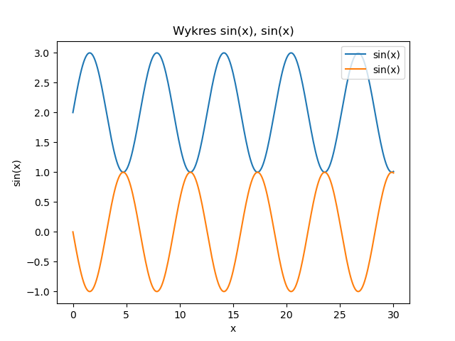

**Zadanie 5**  
Korzystając ze zbioru danych Iris (https://archive.ics.uci.edu/ml/datasets/iris) wygeneruj wykres punktowy, gdzie wektor x to wartość ‘sepal length’ a y to ‘sepal width’, dodaj paletę kolorów c (na przykładzie kodu z podpunktu 2. Wykres punktowy), a parametr s niech będzie wartością bezwzględną z różnicy wartości poszczególnych elementów wektorów x oraz y.

**Zadanie 6**  
Korzystając z biblioteki pandas wczytaj zbiór danych z narodzinami dzieci (`imiona.xlsx`). Następnie na jednym płótnie wyświetl 3 wykresy (jeden wiersz i 3 kolumny). Dodaj do wykresów stosowne etykiety. Poustawiaj różne kolory dla wykresów.  
1 wykres – wykres słupkowy przedstawiający ilość narodzonych dziewczynek i chłopców w całym datasecie.  
2 wykres – wykres liniowy, gdzie będą dwie linie, jedna dla ilości urodzonych kobiet, druga dla mężczyzn dla każdego roku z osobna. Czyli y to ilość narodzonych kobiet lub mężczyzn (dwie linie), x to rok.  
3 wykres – wykres słupkowy przedstawiający sumę urodzonych dzieci w każdym roku.

**Zadanie 7**  
Napisz funkcję, która losowo rzuca dwiema kostkami d6 n razy. Wynik rzutów zapisywany jest w postaci listy sum oczek z tych dwóch kostek. Np. rzucaj(6) generuje 6 rzutów kostkami i zwraca wektor 6 sum oczek każdego rzutu. Po zakończeniu funkcji wyświetlaj histogram sumy rzutów. Dodaj stosowne etykiety do wykresu.

**Zadanie 8**  
Korzystając z pliku `zamówienia.csv` (Pandas) policz sumy zamówień dla każdego sprzedawcy i wyświetl wykres kołowy z procentowym udziałem każdego sprzedawcy w ogólnej sumie zamówień.

Dla chętnych:  
**Zadanie 9**  
Poszukaj w bibliotece wykresów (https://matplotlib.org/stable/gallery/index.html) przykładów z adnotacjami (annotating plots) na wykresach i dodaj adnotacje do dwóch wybranych stworzonych wcześniej wykresów.